# Finding your way around geosmooth

`geosmooth` estimates a response or probability mass on coordinate data and graphs. Start with the task you want to perform, then choose a method. You do not need to learn the operator constructors or synthetic-data helpers to fit your first model.

## Choose a starting point

[output not shown]

These choices describe different estimators, not a ranking of predictive performance. Parallel-transport trend filtering and transported graph Hessians have their own experimental section.

## A first regression fit

Use `X` with one observation per row and a response `y` of matching length. A local chart is a coordinate system fitted near an observation, often using principal component analysis (PCA). Start in the supplied coordinates before adding local charts or changing numerical controls.

```r
library(geosmooth)
set.seed(1)
X <- matrix(seq(0, 1, length.out = 60), ncol = 1)
truth <- sin(2 * pi * X[, 1])
y <- truth + rnorm(nrow(X), sd = 0.08)
fit <- fit.lps(
  X, y, foldid = rep(1:5, length.out = nrow(X)),
  support.grid = c(8L, 12L, 16L), degree.grid = 0:1,
  kernel.grid = "gaussian"
)
fit$selected
```

```
#>   support.size degree   kernel bandwidth.multiplier candidate.id chart.dim
#> 4            8      1 gaussian                    1            4         1
#>   cv.rmse.observed
#> 4       0.07990112
```

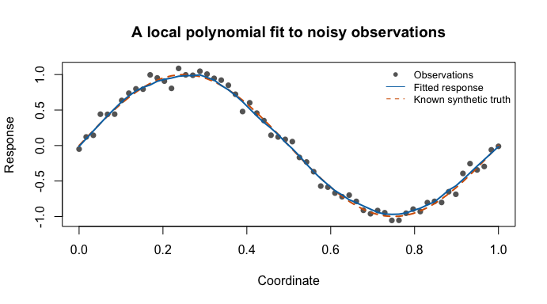

The points are noisy observations. The solid blue line is the selected fit; the dashed orange line is known only because these data are synthetic.

Here CV selected 8-point neighborhoods, degree 1, and the Gaussian kernel, with a tuning RMSE of 0.0799 response units. A larger support averages more nearby responses; the polynomial degree determines the local shape. The selected CV score was used for tuning, so it is not an independent measure of performance. This small illustration shows how to read a fit; it does not rank estimators.

```r
head(fitted(fit))
```

```
#> [1] -0.01193899  0.09633293  0.20478722  0.31316459  0.41899355  0.52015223
```

```r
new.X <- matrix(seq(0.1, 0.9, length.out = 5), ncol = 1)
predict(fit, newdata = new.X)
```

```
#> [1]  0.593224184  0.978163565  0.003195166 -0.910822694 -0.559835093
```

Cross-validation (CV) holds out responses to choose tuning parameters. A support is the neighborhood used for a local fit; a grid lists candidate values. The local support size and polynomial degree jointly determine whether a local fit has enough observations. For grouped observations, use [`lps.grouped.foldid()`](https://pgajer.github.io/geosmooth/reference/lps.grouped.foldid.html) to keep each group in one fold. Use [`lps.nested.cv()`](https://pgajer.github.io/geosmooth/reference/lps.nested.cv.html) when you need an outer assessment of the whole tuning procedure.

### Prediction and reusable fits

| Fitted object | How to get predictions | Scope |
| --- | --- | --- |
| Local polynomial smoother | `predict(fit)` or `predict(fit, newdata = Xnew)` | Existing evaluation points or new coordinate rows. |
| Model-averaged local polynomial smoother | `predict(fit)` or `predict(fit, newdata = Xnew)` | New coordinates are supported for coordinate-distance fits; graph-geodesic fits currently reject new targets. |
| Either lifting trend filter | `predict(fit)` | Training points only; `newdata` must be `NULL`. |
| Prediction-synchronized, chart-kernel, local-likelihood, graph low-pass, graph trend-filtering, Hessian, or parallel-transport fit | `fitted(fit)` | No registered `predict()` method for these classes in this version. Chart-kernel and local-likelihood fits can receive `X.eval` when fitting. |
| Density or occupation-density result | `fit$rho` | Probability mass on the evaluation support. |
| Tracked harmonic result (`harmonic.smoother()`) | `fitted(fit)` | Values on the original graph vertices. |
| Basic harmonic result (`perform.harmonic.smoothing()`) | `fit$harmonic_predictions` | An unclassed list; retains the basic function’s original contract. |

Use `summary(fit)` for selected settings and stored diagnostics. The summary explicitly says when convergence information is unavailable. `fitted(fit)` preserves the vector or matrix stored by each regression fit. `residuals(fit)` preserves missing-label masks and requires an aligned response: a fit evaluated at other coordinates has no training residuals. These are response-scale residuals, including for binomial fits; they are not Pearson or deviance residuals. See `help("model-values", package = "geosmooth")` and `help("model-summary", package = "geosmooth")` for the contracts. Probability mass remains `fit$rho`; it is a different quantity.

A *refit* changes the response while reusing geometry or an operator. It does not automatically rerun the original model-selection procedure. Each refit method documents whether penalties remain fixed or can be selected again. An *operator* describes the differences or derivatives being penalized; it is not itself a fitted response. A *spectral basis* stores graph eigenvectors so many responses can be smoothed without recomputing them.

### Refit and extract smoother matrices

Use `refit(fit, y = new.y, ...)` for all six reusable model families. R chooses the method from the fitted object’s class. The controls in the last column belong to that method; they are not shared by every model.

| Fitted model | Accepted response | Geometry reused and tuning behavior |
| --- | --- | --- |
| MALPS | Vector; omitted or `NULL` reuses the stored response | Supports and averaging weights stay fixed. Optional `weights` affect local coefficient estimation; robust residual weights are recomputed. |
| Lifting trend filter | Vector required | Reuses the residual operator and stored penalty, or accepts a fixed `lambda`. |
| Synchronized lifting trend filter | Vector required | Reuses both operators and stored penalties, or accepts fixed `lambda1` and `lambda2`. |
| Metric graph low-pass | Vector or matrix required | Reuses the spectral basis and smoothing parameter; `per.column.gcv = TRUE` selects a parameter for each response column. |
| Quadratic Hessian-energy regression | Vector or matrix; omitted or `NULL` reuses the stored response | Reuses the operator and fixed penalties; accepts `lambda1`, `lambda2`, `weights`, and `ridge`. CV/GCV fits dispatch here and retain their selected penalties by default. |
| Hessian L1 regression | One response; omitted or `NULL` reuses the stored response | Reuses the derivative operator; accepts `lambda.grid`, fixed or CV `lambda.selection`, and solver controls. |

For repeated metric graph low-pass or quadratic Hessian refits, keep using the original fitted object. Their returned refit summaries cannot themselves be refitted. The other four families return reusable fitted objects.

Use `smoother.matrix(fit, ...)` for LPS and MALPS. LPS accepts `check.tol` and returns a map from training responses to evaluation predictions under its fixed-configuration restrictions. MALPS accepts `max.n` and `allow.robust` and returns a training-point matrix conditional on stored supports and weights. For robust MALPS, `allow.robust = TRUE` freezes the final robust weights; it does not capture their response-dependent changes.

```r
malps.fit <- fit.malps(
  X, y, degree = 1L, support.type = "knn", support.size = 12L
)
new.y <- cos(2 * pi * X[, 1])
malps.refit <- refit(malps.fit, y = new.y)
S <- smoother.matrix(malps.fit)
max(abs(as.vector(S %*% new.y) - predict(malps.refit)))
```

```
#> [1] 4.440892e-16
```

The former six `refit.*()` entry points and two `*.smoother.matrix()` entry points are no longer exported. Replace `fitted.model =` with `object =` and `y.new =` with `y =` in old refit calls. Other method-specific arguments and return classes are unchanged. `help("refit", package = "geosmooth")` and `help("smoother.matrix", package = "geosmooth")` link to each method’s full argument list; former help names remain available.

## Function catalog

Each row in the geosmooth catalog gives one exported name and its purpose. In an R session, open the corresponding help with, for example, `help("fit.lps", package = "geosmooth")`. The final two sections explicitly list related functions owned by `dgraphs`; they are not geosmooth exports, and their detailed help lives in dgraphs.

### Shared model operations

| Function | Purpose |
| --- | --- |
| [`refit()`](https://pgajer.github.io/geosmooth/reference/refit.html) | Refit a supported model with a new response using stored geometry and method-specific tuning controls. |
| [`smoother.matrix()`](https://pgajer.github.io/geosmooth/reference/smoother.matrix.html) | Extract the conditional linear map for a supported LPS or MALPS fit. |

### Local regression and prediction synchronization

| Function | Purpose |
| --- | --- |
| [`fit.lps()`](https://pgajer.github.io/geosmooth/reference/fit.lps.html) | Fit and tune local polynomial regression, including supported Gaussian and binary response modes. |
| [`fit.malps()`](https://pgajer.github.io/geosmooth/reference/fit.malps.html) | Fit and optionally tune a model-averaged collection of local polynomial models. |
| [`fit.ps.lps()`](https://pgajer.github.io/geosmooth/reference/fit.ps.lps.html) | Fit experimental local polynomial models whose predictions are synchronized on overlaps. |
| [`fit.chart.kernel()`](https://pgajer.github.io/geosmooth/reference/fit.chart.kernel.html) | Fit a chart-kernel field, with optional reference-measure quadrature weights. |
| [`fit.local.likelihood()`](https://pgajer.github.io/geosmooth/reference/fit.local.likelihood.html) | Fit local density or Bernoulli likelihood models; returns a fitted field. |

### Model assessment and uncertainty

| Function | Purpose |
| --- | --- |
| [`lps.grouped.foldid()`](https://pgajer.github.io/geosmooth/reference/lps.grouped.foldid.html) | Assign whole groups of observations to validation folds. |
| [`lps.nested.cv()`](https://pgajer.github.io/geosmooth/reference/lps.nested.cv.html) | Assess a tuned local polynomial smoother using outer and inner validation folds. |
| [`lps.backend.diagnostics()`](https://pgajer.github.io/geosmooth/reference/lps.backend.diagnostics.html) | Inspect the computational backend, chart dimensions, and selected controls. |
| [`lps.pointwise.band()`](https://pgajer.github.io/geosmooth/reference/lps.pointwise.band.html) | Calculate pointwise uncertainty for a supported fixed-configuration Gaussian fit. |
| [`malps.gcv()`](https://pgajer.github.io/geosmooth/reference/malps.gcv.html) | Calculate generalized cross-validation and optional leave-one-out diagnostics for a stored model-averaged fit. |
| [`bootstrap.malps()`](https://pgajer.github.io/geosmooth/reference/bootstrap.malps.html) | Measure refit variability by bootstrap case weights while holding the selected geometry fixed. |

Generalized cross-validation (GCV) uses a smoother’s effective degrees of freedom to estimate prediction error without explicitly fitting every leave-one-out model. It is not interchangeable with every form of CV.

The two uncertainty workflows have different assumptions. LPS uncertainty requires a Gaussian fit, the R backend, the documented orthogonal polynomial basis, a single candidate configuration, and a fixed chart dimension. Its pointwise band also requires evaluation at the training points. MALPS matrix and bootstrap diagnostics condition on the selected supports and weights; they do not repeat model selection. Neither workflow provides simultaneous coverage or automatic uncertainty for a full data-selected pipeline.

### Lifting trend filters

| Function | Purpose |
| --- | --- |
| [`lpl.tf.operator()`](https://pgajer.github.io/geosmooth/reference/lpl.tf.operator.html) | Build a local polynomial residual operator. |
| [`fit.lpl.tf()`](https://pgajer.github.io/geosmooth/reference/fit.lpl.tf.html) | Fit a trend filter with an absolute-value penalty on those residuals. |
| [`slpl.tf.operator()`](https://pgajer.github.io/geosmooth/reference/slpl.tf.operator.html) | Build the residual operator together with an overlap synchronization operator. |
| [`fit.slpl.tf()`](https://pgajer.github.io/geosmooth/reference/fit.slpl.tf.html) | Fit the residual penalty plus quadratic synchronization. |

Both fitters accept a prebuilt operator or can construct one. For a single fit, start with the fitter. Build operators explicitly when comparing responses, studying neighborhoods, or reusing expensive geometry. Both fitters currently require `genlasso`; their supported prediction domain is the training set.

### Graph spectral smoothing and graph trend filtering

| Function | Purpose |
| --- | --- |
| [`fit.metric.graph.lowpass()`](https://pgajer.github.io/geosmooth/reference/fit.metric.graph.lowpass.html) | Select a graph-spectral smoothing parameter by GCV and fit a response. |
| [`metric.graph.lowpass.operator()`](https://pgajer.github.io/geosmooth/reference/metric.graph.lowpass.operator.html) | Convert metric edge lengths to conductances and construct a graph Laplacian. |
| [`metric.graph.lowpass.basis()`](https://pgajer.github.io/geosmooth/reference/metric.graph.lowpass.basis.html) | Construct and retain graph eigenvectors for repeated smoothing. |
| [`apply.metric.graph.lowpass.path()`](https://pgajer.github.io/geosmooth/reference/apply.metric.graph.lowpass.path.html) | Apply a supplied basis over a parameter grid; retain the candidate fits. |
| [`metric.graph.heat.eta.grid()`](https://pgajer.github.io/geosmooth/reference/metric.graph.heat.eta.grid.html) | Choose heat-time candidates using spectral information. |
| [`metric.graph.heat.extend.lower()`](https://pgajer.github.io/geosmooth/reference/metric.graph.heat.extend.lower.html) | Propose a smaller heat time for an external search, subject to resolution safeguards. |
| [`graph.trend.filtering.operator()`](https://pgajer.github.io/geosmooth/reference/graph.trend.filtering.operator.html) | Construct graph differences or experimental path divided differences. |
| [`fit.graph.trend.filtering()`](https://pgajer.github.io/geosmooth/reference/fit.graph.trend.filtering.html) | Fit an absolute-value graph-difference penalty; requires `genlasso`. |

Graph construction and shortest paths are supplied by `dgraphs`. A graph’s adjacency list contains 1-based vertex indices; a parallel weight list gives the corresponding edge values. **Check their meaning for the chosen method:** metric low-pass smoothing interprets them as lengths and converts them to conductances. Recursive graph trend filtering uses conductance-like weights, whereas its path divided-difference option uses lengths. Conductance measures connection strength; it is not the same quantity as distance.

Heat time (`eta`) controls the amount of spectral smoothing. A truncated basis can fail to resolve small positive heat times; use the returned spectral diagnostics when constructing or extending a path yourself.

#### From a constructed graph to a fitted response

This example uses the tested development dependency described in the README; the compatible dgraphs release must be on CRAN before geosmooth 0.2.0 is submitted. The 20 locations form an undirected chain because the construction radius joins only adjacent sites. Vertex *i*, coordinate row *i*, and response entry *i* refer to the same observation. Retain your identifiers in a separate table and join by those identifiers before fitting; a smoother cannot detect a shuffled response.

```r
# Each row, vertex, and response refers to the same location.
locations <- matrix(seq(0, 1, length.out = 20), ncol = 1,
                    dimnames = list(sprintf("site-%02d", 1:20), "position"))
response <- sin(2 * pi * locations[, 1])
graph <- dgraphs::create.rknn.graph(locations, radius = .06,
                                    graph.detail = "minimal")
# dgraphs' new dgraph representation has public accessors. The second branch
# supports the pinned transitional dependency used by this development release.
if (inherits(graph, "dgraph")) {
  adjacency <- dgraphs::graph.adjacency(graph)
  edge.lengths <- dgraphs::graph.lengths(graph)
} else {
  adjacency <- graph$adj_list
  edge.lengths <- graph$weight_list
}
graph.fit <- fit.metric.graph.lowpass(
  adjacency, edge.lengths, response,
  n.eigenpairs = nrow(locations), eigen.solver = "dense",
  conductance.rule = "inverse.length.power", conductance.alpha = 1,
  conductance.epsilon = 1e-8, eta.grid = c(.001, .01, .1, 1)
)
head(data.frame(site = rownames(locations), response,
                fitted = fitted(graph.fit)))
```

```
#>            site  response      fitted
#> site-01 site-01 0.0000000 0.006105107
#> site-02 site-02 0.3246995 0.324089090
#> site-03 site-03 0.6142127 0.612949746
#> site-04 site-04 0.8371665 0.835444574
#> site-05 site-05 0.9694003 0.967406378
#> site-06 site-06 0.9965845 0.994534692
```

```r
graph.fit$gcv[c("eta.optimal", "gcv.optimal", "effective.df")]
```

```
#> $eta.optimal
#> [1] 0.001
#>
#> $gcv.optimal
#> [1] 0.0002323874
#>
#> $effective.df
#> [1] 19.2978
```

```r
# Reuse the fitted object's spectral basis, with the selected smoothing fixed.
second.fit <- refit(graph.fit, y = cos(2 * pi * locations[, 1]))
head(fitted(second.fit))
```

```
#> [1]  0.99896194  0.94388145  0.78751744  0.54582318  0.24498057 -0.08240949
```

With `conductance.alpha = 1`, a length of 2 becomes a conductance of `1 / (2 + 1e-8)`, approximately 0.5. Longer edges therefore connect responses less strongly. This choice changes the smoothing operator; it is not just a change of labels. The example retains all eigenvectors, so no spectral truncation is involved. For large graphs, use the spectral diagnostics described in `help("metric.graph.lowpass.basis")` when retaining fewer eigenvectors. The second response reuses those eigenvectors and the selected heat time. The printed GCV score is a tuning criterion, not held-out predictive error.

| Input context | Meaning | Consequence |
| --- | --- | --- |
| Coordinate neighborhoods | Distances in the supplied coordinate units | Rescaling coordinates changes supports. |
| Graph-geodesic neighborhoods | Sums of edge lengths along paths | Unreachable vertices have infinite distance; support rules must handle connectivity. |
| Metric low-pass smoothing | Positive lengths transformed to conductances | Reciprocal edges and matching lengths are required; zero lengths are rejected. |
| Recursive graph differences | Conductance-like weights | Greater weight penalizes differences more strongly. |
| Path divided differences | Edge lengths | The operator uses metric spacing, not conductance. |

For example, `metric.graph.lowpass.operator(list(2L, integer()), list(1, numeric()))` is rejected because the edge has no reciprocal entry. Do not repair directed or zero-length input silently. Resolve its scientific meaning before choosing a supported undirected positive-length graph.

### Hessian-energy regression

| Function | Purpose |
| --- | --- |
| [`ssrhe.hessian.operator()`](https://pgajer.github.io/geosmooth/reference/ssrhe.hessian.operator.html) | Estimate local derivative operators and Hessian-energy matrices from point-cloud neighborhoods. |
| [`fit.ssrhe.hessian.regression()`](https://pgajer.github.io/geosmooth/reference/fit.ssrhe.hessian.regression.html) | Fit quadratic Hessian-energy regression using fixed penalties, label CV, or GCV; optionally select supports. |
| [`fit.ssrhe.hessian.l1.regression()`](https://pgajer.github.io/geosmooth/reference/fit.ssrhe.hessian.l1.regression.html) | Fit an absolute-value derivative penalty with fixed or CV-selected regularization. |
| [`ssrhe.support.grid()`](https://pgajer.github.io/geosmooth/reference/ssrhe.support.grid.html) | Build candidate adaptive-radius support profiles for tuning. |

The Hessian describes local second derivatives. A quadratic penalty spreads curvature reduction across the fitted field; an absolute-value penalty can set derivative components to zero. These are different estimators.

Label CV supports semi-supervised use: some vertices may lack an observed response. GCV currently requires one fully observed response vector and strictly positive observation weights. Exact GCV traces and randomized trace estimates have different computational costs and reproducibility properties. For the absolute-value fitter, `solver = "admm"` selects the implemented alternating direction method of multipliers; the `genlasso` solver requires that optional package.

To select quadratic Hessian penalties, use the same fitter with an explicit selection mode. Mode-specific settings belong in `cv.control` or `gcv.control`. Scalar penalties and candidate grids cannot be combined.

```r
hessian.fit <- fit.ssrhe.hessian.regression(
  X, y, k = 12L, tangent.dim = 1L,
  lambda.selection = "cv", lambda1.grid = c(0.01, 0.1),
  cv.control = list(foldid = rep(1:5, length.out = nrow(X)))
)
hessian.fit$lambda
```

```
#> $lambda1
#> [1] 0.01
#>
#> $lambda2
#> [1] 0
#>
#> $ridge
#> [1] 0
```

The former `.cv()` and `.gcv()` fitter names have been retired. Their old help names still lead to the unified fitter’s migration instructions. Existing fixed calls with `lambda1` and optional `lambda2` continue to work.

### Harmonic interpolation

| Function | Purpose |
| --- | --- |
| [`perform.harmonic.smoothing()`](https://pgajer.github.io/geosmooth/reference/perform.harmonic.smoothing.html) | Relax interior values while holding the region boundary fixed; return convergence diagnostics. |
| [`harmonic.smoother()`](https://pgajer.github.io/geosmooth/reference/harmonic.smoother.html) | Run relaxation while recording extrema, prediction history, and topology stability. |
| [`get.region.boundary()`](https://pgajer.github.io/geosmooth/reference/get.region.boundary.html) | Find region vertices with a neighbor outside the region. |

Use `print()`, `summary()`, and `plot()` on the tracked `harmonic_smoother` object. The two smoothing functions currently differ in boundary-free behavior so they should not be treated as aliases. In the current native implementation, boundary vertices are defined by a neighbor outside the region; a degree-one vertex inside a whole-graph region is not automatically fixed. The basic function returns unchanged input with `status = "no_boundary"` when no boundary exists; the tracked function still runs relaxation. Both require small value changes and a small harmonic residual for numerical convergence. Extrema stability is a separate diagnostic: `stability_detected` records whether a window was found, and `stable_iteration` is `NA` otherwise. On an alternating path, recording every second iteration can appear stable while the values continue to oscillate. Check `converged` and `max_residual`; a stability detection does not establish optimal smoothing.

### Probability mass and subject occupation

| Function | Purpose |
| --- | --- |
| [`fit.density()`](https://pgajer.github.io/geosmooth/reference/fit.density.html) | Fit empirical or graph-random-walk mass estimates from nonnegative weights on a support. |
| [`normalize.density()`](https://pgajer.github.io/geosmooth/reference/normalize.density.html) | Convert a numeric field or supported fitted object to probability mass, with normalization diagnostics. |
| [`fit.subject.od()`](https://pgajer.github.io/geosmooth/reference/fit.subject.od.html) | Convert repeated visit indices into counts and fit a subject-occupation distribution. |

```r
support <- matrix(seq(0, 1, length.out = 6), ncol = 1)
occupation <- fit.subject.od(
  support, subject.index = c(1L, 3L, 3L, 6L), method = "empirical"
)
occupation$rho
```

```
#> [1] 0.25 0.00 0.50 0.00 0.00 0.25
```

```r
sum(occupation$rho)
```

```
#> [1] 1
```

Here the third support point receives twice as many visits as the first or sixth. `rho` is a probability **mass** vector over support points, summing to one; it is not automatically a continuous density per unit volume. [`normalize.density()`](https://pgajer.github.io/geosmooth/reference/normalize.density.html) is an explicit conversion step, not another regression fit. Inspect its clipping and normalization accounting when the source field contains negative values.

[`fit.subject.od()`](https://pgajer.github.io/geosmooth/reference/fit.subject.od.html) offers more methods than [`fit.density()`](https://pgajer.github.io/geosmooth/reference/fit.density.html): it can fit ordinary smoothers and normalize their output. Visit-level CV holds out visits and uses `visit.foldid`; ordinary regression CV holds out support rows and uses `foldid` (or the method-specific spelling). Keep these validation units distinct.

### Experimental transport methods

| Function | Purpose |
| --- | --- |
| [`pttf.geometry()`](https://pgajer.github.io/geosmooth/reference/pttf.geometry.html) | Build local tangent frames and their transport across a graph. |
| [`pttf.operator()`](https://pgajer.github.io/geosmooth/reference/pttf.operator.html) | Construct parallel-transport trend-filtering differences from that geometry. |
| [`pttf.operator.filter.rows()`](https://pgajer.github.io/geosmooth/reference/pttf.operator.filter.rows.html) | Select operator rows while maintaining provenance and related operator data. |
| [`fit.pttf.trend.filtering()`](https://pgajer.github.io/geosmooth/reference/fit.pttf.trend.filtering.html) | Fit a parallel-transport trend filter with an absolute-value or quadratic penalty. |
| [`transported.graph.hessian.operator()`](https://pgajer.github.io/geosmooth/reference/transported.graph.hessian.operator.html) | Build a separate experimental graph Hessian diagnostic with several direction-matching rules. |

Parallel transport aligns local tangent directions before comparing derivatives. These experimental interfaces expose geometry, operator, and solver diagnostics deliberately. The transported graph Hessian constructor is a separate diagnostic workflow; it does not fit a response and is not an interchangeable spelling of [`pttf.operator()`](https://pgajer.github.io/geosmooth/reference/pttf.operator.html).

### Synthetic datasets: specifications, responses, and reproducibility

| Function | Purpose |
| --- | --- |
| [`synthetic.spec()`](https://pgajer.github.io/geosmooth/reference/synthetic.spec.html) | Combine geometry, sampling, truth, and response descriptors without drawing data. |
| [`materialize.synthetic()`](https://pgajer.github.io/geosmooth/reference/materialize.synthetic.html) | Draw a dataset from a specification with an explicit seed and random-number policy. |
| [`materialize.synthetic.instance()`](https://pgajer.github.io/geosmooth/reference/materialize.synthetic.instance.html) | Reproduce a registered frozen instance and optionally validate its checksum. |
| [`synthetic.registry.ids()`](https://pgajer.github.io/geosmooth/reference/synthetic.registry.ids.html) | List maintained recipe identifiers. |
| [`synthetic.registry.spec()`](https://pgajer.github.io/geosmooth/reference/synthetic.registry.spec.html) | Look up a recipe specification; some recipe families allow parameter overrides. |
| [`synthetic.registry.seed()`](https://pgajer.github.io/geosmooth/reference/synthetic.registry.seed.html) | Reproduce legacy SSRHE recipe seeds; this is not a seed generator for every registry family. |
| [`validate.synthetic.dataset()`](https://pgajer.github.io/geosmooth/reference/validate.synthetic.dataset.html) | Check the structure and consistency of a materialized dataset. |
| [`compare.synthetic.dataset()`](https://pgajer.github.io/geosmooth/reference/compare.synthetic.dataset.html) | Compare two datasets with explicit numerical tolerances. |
| [`synthetic.dataset.checksum()`](https://pgajer.github.io/geosmooth/reference/synthetic.dataset.checksum.html) | Compute a content checksum for reproducibility checks. |
| [`synthetic.sampling.stratified()`](https://pgajer.github.io/geosmooth/reference/synthetic.sampling.stratified.html) | Describe allocation between the supported synthetic strata. |
| [`synthetic.truth.named()`](https://pgajer.github.io/geosmooth/reference/synthetic.truth.named.html) | Select a named truth specification with optional parameters. |
| [`synthetic.truth.polynomial()`](https://pgajer.github.io/geosmooth/reference/synthetic.truth.polynomial.html) | Specify polynomial truth in the chosen evaluation coordinates. |
| [`synthetic.truth.gaussian.mixture()`](https://pgajer.github.io/geosmooth/reference/synthetic.truth.gaussian.mixture.html) | Specify Gaussian-mixture truth using centers, scales, and weights. |
| [`synthetic.truth.occupation.mixture()`](https://pgajer.github.io/geosmooth/reference/synthetic.truth.occupation.mixture.html) | Specify occupation-mixture truth with covariance and probability controls. |
| [`synthetic.truth.logit()`](https://pgajer.github.io/geosmooth/reference/synthetic.truth.logit.html) | Specify a logit-based truth with prevalence and clipping controls. |
| [`synthetic.response.gaussian()`](https://pgajer.github.io/geosmooth/reference/synthetic.response.gaussian.html) | Specify Gaussian response noise with a supplied standard deviation. |
| [`synthetic.response.heteroskedastic.gaussian()`](https://pgajer.github.io/geosmooth/reference/synthetic.response.heteroskedastic.gaussian.html) | Specify Gaussian noise whose scale depends on truth. |
| [`synthetic.response.clustered.gaussian()`](https://pgajer.github.io/geosmooth/reference/synthetic.response.clustered.gaussian.html) | Specify within-cluster correlated Gaussian noise. |
| [`synthetic.response.laplace.outlier()`](https://pgajer.github.io/geosmooth/reference/synthetic.response.laplace.outlier.html) | Specify Laplace noise and an outlier component. |
| [`synthetic.response.bernoulli()`](https://pgajer.github.io/geosmooth/reference/synthetic.response.bernoulli.html) | Specify binary response draws and optional positive-count requirements. |

The constructors create specifications; [`materialize.synthetic()`](https://pgajer.github.io/geosmooth/reference/materialize.synthetic.html) performs random draws. Use `print()`, `plot()`, and `as.data.frame()` on a resulting `synthetic_dataset`. For complete examples, read `vignette("synthetic-datasets", package = "geosmooth")`. Use the named-stream random-number policy for new work; historical seed and algorithm controls preserve frozen examples and should not be changed casually.

### Geometry constructors and helpers supplied by dgraphs

These names are available from `dgraphs`, and are no longer exported by `geosmooth`. Replace former `geosmooth::` calls with `dgraphs::`. See, for example, `help("synthetic.circle", package = "dgraphs")`.

| Function | Purpose |
| --- | --- |
| `dgraphs::synthetic.circle()` | Describe a circle or circular arc and its embedding. |
| `dgraphs::synthetic.helix()` | Describe a helical curve. |
| `dgraphs::synthetic.trefoil()` | Describe a trefoil curve. |
| `dgraphs::synthetic.torus.patch()` | Describe a patch of a torus. |
| `dgraphs::synthetic.sphere.cap()` | Describe a spherical cap. |
| `dgraphs::synthetic.quadform()` | Describe a flat or quadratic geometry with intrinsic and ambient dimensions. |
| `dgraphs::synthetic.simplex()` | Describe a simplex with a given number of parts. |
| `dgraphs::synthetic.stratified()` | Combine strata and optional junctions. |
| `dgraphs::synthetic.stratum.point()` | Describe a point stratum. |
| `dgraphs::synthetic.stratum.segment()` | Describe a line-segment stratum. |
| `dgraphs::synthetic.stratum.rectangle()` | Describe a rectangular stratum. |
| `dgraphs::synthetic.point.line.junction()` | Describe a point-and-line junction geometry. |
| `dgraphs::embed.synthetic.geometry()` | Map latent coordinates to the ambient space. |
| `dgraphs::edge.lengths.synthetic.geometry()` | Evaluate geometry-aware lengths between latent endpoints. |
| `dgraphs::quadform.gradient()` | Evaluate the gradient of a quadratic geometry. |
| `dgraphs::quadform.metric()` | Evaluate its induced metric. |

### Sampling constructors supplied by dgraphs

| Function | Purpose |
| --- | --- |
| `dgraphs::synthetic.sampling.uniform.interval()` | Describe uniform draws on an interval. |
| `dgraphs::synthetic.sampling.uniform.box()` | Describe uniform draws in a box. |
| `dgraphs::synthetic.sampling.uniform.rectangle()` | Describe uniform draws in a rectangle with its specified draw algorithm. |
| `dgraphs::synthetic.sampling.uniform.disk()` | Describe uniform draws in a disk. |
| `dgraphs::synthetic.sampling.grid.interval()` | Describe an interval grid with an endpoint convention. |
| `dgraphs::synthetic.sampling.gapped.uniform()` | Describe sampling across separated intervals. |
| `dgraphs::synthetic.sampling.truncated.normal()` | Describe bounded Gaussian draws. |
| `dgraphs::synthetic.sampling.clustered()` | Describe clustered observations around random centers. |
| `dgraphs::synthetic.sampling.dirichlet.zeros()` | Describe Dirichlet sampling with structural zeros. |

Similar geometric domains do not imply identical random-number sequences: these descriptors also preserve ordering and algorithm choices.

## Finding detailed help

Function links in this guide open the rendered online reference. When working without an internet connection, the same help is installed with the package: use `help("fit.lps", package = "geosmooth")`, replacing `fit.lps` with the function name. Start at `help("geosmooth-package", package = "geosmooth")` for clickable task links in installed help, or use `browseVignettes("geosmooth")` for the installed HTML guides.

The synthetic datasets guide develops reproducible geometry, sampling, truth, and response specifications in more detail.

```r
help(package = "geosmooth")
help("geosmooth-package", package = "geosmooth")
help("fit.lps", package = "geosmooth")
help("predict.lps", package = "geosmooth")
vignette("function-guide", package = "geosmooth")
vignette("synthetic-datasets", package = "geosmooth")
```

The package’s help pages give exact arguments, defaults, return values, and examples. Use this guide to find the appropriate family, then read the chosen function’s help before configuring its advanced controls.

## Advanced controls without a new fitter

Each main fitter’s installed help groups controls for a first fit, selection, geometry, numerical solving, and returned diagnostics. Begin with a small statistical grid; numerical tolerances do not replace statistical tuning.

| Family | Fold and selection vocabulary | Meaning and main cost |
| --- | --- | --- |
| LPS / MALPS | `foldid`, `cv.folds`, support/degree/kernel grids | Held-out response selection; candidate combinations multiply fitting work. |
| Quadratic Hessian | `lambda.selection`, `cv.control`, `gcv.control` | Label CV or GCV; exact trace calculation is more expensive than sampled traces. |
| Hessian L1 | `fold.id`, `nfolds`, `lambda.grid`, `admm.*` | CV excludes unconverged solves; each candidate and fold needs a solve. |
| Graph low-pass | `eta.grid`, `n.eigenpairs` | GCV over heat times; a full spectral basis uses quadratic storage. |

`smoother.matrix()` returns a dense evaluation-by-training matrix. Retained candidate fits and solver histories also consume memory. Request them for an actual diagnostic purpose. These differences are deliberate method contracts; matching argument names would not make the criteria equivalent.

The catalog covers all explicitly exported functions in geosmooth 0.2.0. Geometry and sampling functions are owned by dgraphs. Registered methods are accessed through familiar generics; use the installed package index for the complete method list rather than treating methods as additional fitters.